# Criteria for model selection

Przemyslaw Biecek

Linear models with fixed and random effects

# Five variables in simulation study

```r
set.seed(1313)
n <- 500
p <- 15
imp <- 5
# coefficients
beta <- c(rep(1,imp),rep(0,p-imp))

# variables
X <- matrix(rnorm(n*p),n,p)
colnames(X) <- paste0("var", 1:p)

# outcome variable
y <- X %*% t(t(beta)) + rnorm(n)

dat <- data.frame(y,X)

# let'ss see the model
summary(lm(y ~ ., data=dat))
```

```
##
## Call:
## lm(formula = y ~ ., data = dat)
##
## Residuals:
##      Min       1Q   Median       3Q      Max
## -2.98405 -0.67528  0.06378  0.69988  2.70983
##
## Coefficients:
##              Estimate Std. Error t value Pr(>|t|)
## (Intercept) -0.086911   0.044268  -1.963   0.0502 .
## var1         0.961565   0.045647  21.065   <2e-16 ***
## var2         1.006171   0.046073  21.839   <2e-16 ***
## var3         1.041926   0.043862  23.755   <2e-16 ***
## var4         1.026384   0.044875  22.872   <2e-16 ***
## var5         1.030433   0.044530  23.140   <2e-16 ***
## var6        -0.020496   0.044429  -0.461   0.6448
## var7         0.025841   0.044435   0.582   0.5611
## var8         0.005865   0.042952   0.137   0.8914
## var9        -0.099180   0.041986  -2.362   0.0186 *
## var10       -0.024905   0.044004  -0.566   0.5717
## var11       -0.026363   0.044570  -0.591   0.5545
## var12        0.007647   0.041335   0.185   0.8533
## var13       -0.018998   0.043854  -0.433   0.6651
## var14        0.066206   0.043554   1.520   0.1291
## var15       -0.031052   0.043621  -0.712   0.4769
## ---
## Signif. codes:  0 '***' 0.001 '**' 0.01 '*' 0.05 '.' 0.1 ' ' 1
##
## Residual standard error: 0.9727 on 484 degrees of freedom
## Multiple R-squared:  0.8529, Adjusted R-squared:  0.8483
## F-statistic: 187.1 on 15 and 484 DF,  p-value: < 2.2e-16
```

# Model selection criteria

Akaike information criterion (AIC) and Bayesian information criterion (BIC) are two coefficients from family of Generalized Information Criterion. Other popular measures of model fit are: R square, adjusted R square or Cp Mallows (this one we are going to discuss next week).

Let’s see how to calculate them.

```r
model <- lm(y ~ ., data=dat)

AIC(model)
```

```
## [1] 1409.028
```

```r
BIC(model)
```

```
## [1] 1480.676
```

```r
summary(model)$r.squared
```

```
## [1] 0.8528996
```

```r
summary(model)$adj.r.squared
```

```
## [1] 0.8483407
```

# Model selection strategies

## Exhaustive search

If the number of variables is not larger than 20 one can consider full / exhaustive search. For larger model one can consider the stepwise algorithm.

```r
# Full search
library(e1071)

comb <- bincombinations(p)[-1,]
crit <- matrix(0, nrow(comb), 5)

for (i in 1:nrow(comb)) {
  form <- paste0("y~",
                 paste0("var",which(comb[i,]==1), collapse="+"))
  model <- lm(as.formula(form), data=dat)
  crit[i,1] <- AIC(model)
  crit[i,2] <- BIC(model)
  crit[i,3] <- summary(model)$r.squared
  crit[i,4] <- summary(model)$adj.r.squared
  crit[i,5] <- sum(comb[i,]==1)
}
colnames(crit) <- c("AIC", "BIC", "R2", "R2adj","p")
crit <- data.frame(crit)
```

## BIC

Which model is the best one when it comes to BIC?

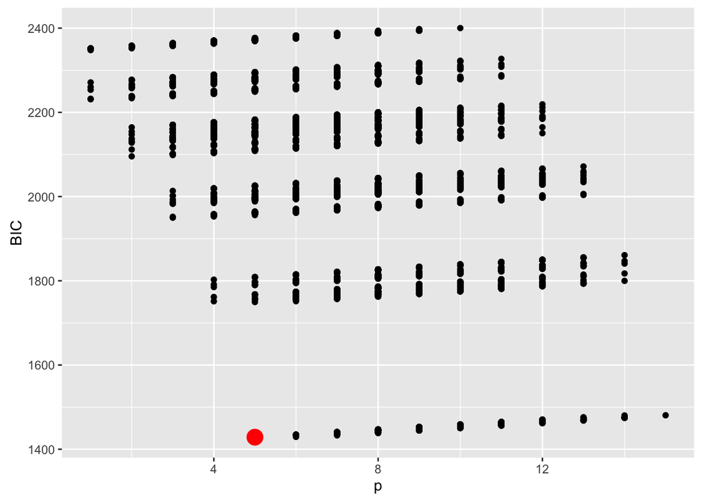

```r
# How it looks like for BIC
library(ggplot2)
ggplot(crit, aes(p,BIC)) +
  geom_point() +
  geom_point(data=crit[which.min(crit$BIC),], color="red", size=5)
```

## AIC

Which model is the best one when it comes to AIC?

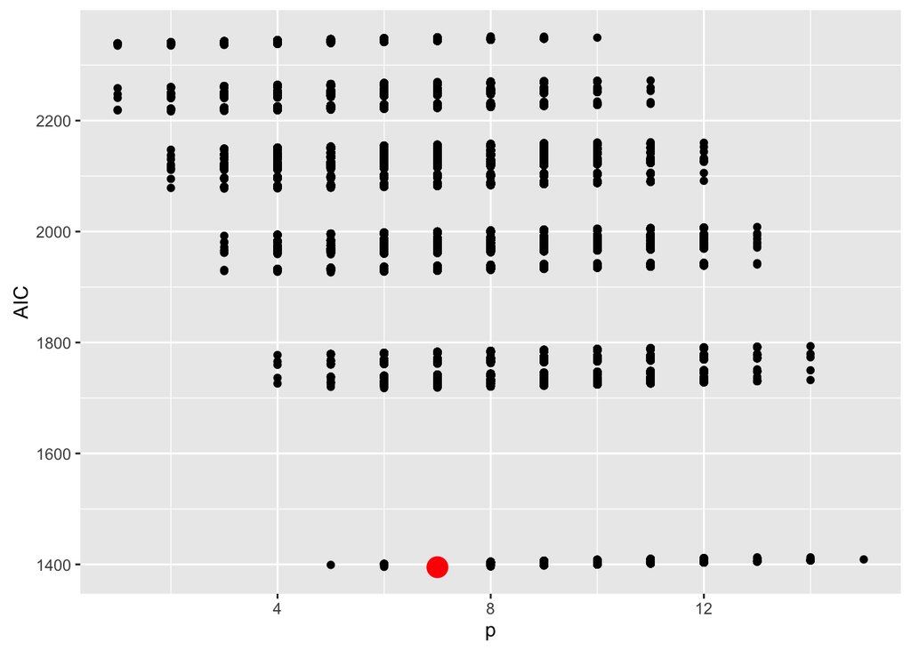

```r
# How it looks like for AIC
library(ggplot2)
ggplot(crit, aes(p,AIC)) +
  geom_point() +
  geom_point(data=crit[which.min(crit$AIC),], color="red", size=5)
```

## R2

Which model is the best one when it comes to R square?

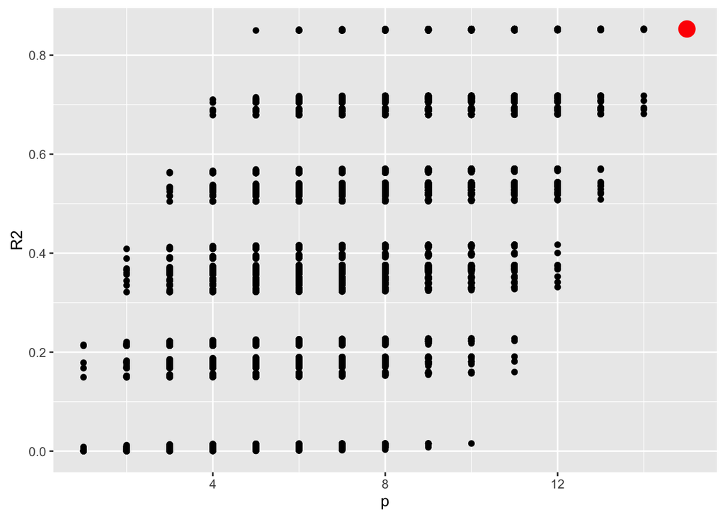

```r
# How it looks like for R2
library(ggplot2)
ggplot(crit, aes(p,R2)) +
  geom_point() +
  geom_point(data=crit[which.max(crit$R2),], color="red", size=5)
```

## R2-adj

Which model is the best one when it comes to adjusted R square?

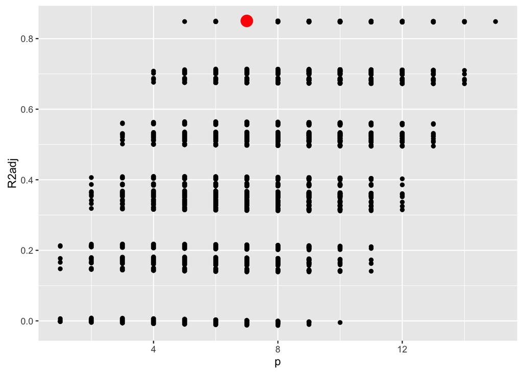

```r
# How it looks like for R2
library(ggplot2)
ggplot(crit, aes(p,R2adj)) +
  geom_point() +
  geom_point(data=crit[which.max(crit$R2adj),], color="red", size=5)
```

## Stepwise strategies

The `step()` function performs a stepwise search. Good starting point is a key.

```r
tmpFun = function(fit, aic) {
  list(size = length(fit$coefficients), bic = BIC(fit))
  }

path <- step(model, direction="backward", keep=tmpFun, k=log(n))
```

```
## Start:  AIC=55.52
## y ~ var1 + var2 + var3 + var4 + var5 + var6 + var7 + var8 + var9 +
##     var10 + var11 + var12 + var13 + var14 + var15
##
##         Df Sum of Sq    RSS    AIC
## - var8   1      0.02 457.98  49.33
## - var12  1      0.03 457.99  49.34
## - var13  1      0.18 458.14  49.50
## - var6   1      0.20 458.16  49.53
## - var10  1      0.30 458.27  49.64
## - var7   1      0.32 458.28  49.66
## - var11  1      0.33 458.29  49.67
## - var15  1      0.48 458.44  49.83
## - var14  1      2.19 460.15  51.69
## - var9   1      5.28 463.24  55.04
## <none>               457.96  55.52
## - var1   1    419.87 877.83 374.64
## - var2   1    451.27 909.23 392.22
## - var4   1    494.98 952.94 415.69
## - var5   1    506.67 964.64 421.79
## - var3   1    533.93 991.89 435.72
##
## Step:  AIC=49.33
## y ~ var1 + var2 + var3 + var4 + var5 + var6 + var7 + var9 + var10 +
##     var11 + var12 + var13 + var14 + var15
##
##         Df Sum of Sq    RSS    AIC
## - var12  1      0.03 458.01  43.15
## - var13  1      0.18 458.16  43.31
## - var6   1      0.20 458.18  43.33
## - var10  1      0.31 458.29  43.45
## - var11  1      0.32 458.30  43.46
## - var7   1      0.33 458.31  43.47
## - var15  1      0.49 458.47  43.65
## - var14  1      2.17 460.15  45.48
## - var9   1      5.26 463.24  48.83
## <none>               457.98  49.33
## - var1   1    419.90 877.88 368.45
## - var2   1    451.31 909.29 386.03
## - var4   1    495.39 953.37 409.70
```

[output cut: 127 more lines]

```
## - var2  1    451.89 914.11 338.96
## - var4  1    502.21 964.42 365.75
## - var5  1    511.89 974.10 370.74
## - var3  1    537.13 999.35 383.54
##
## Step:  AIC=3.47
## y ~ var1 + var2 + var3 + var4 + var5
##
##        Df Sum of Sq    RSS    AIC
## <none>              467.30   3.47
## - var1  1    434.99 902.29 326.24
## - var2  1    453.56 920.87 336.43
## - var4  1    497.92 965.22 359.95
## - var5  1    509.49 976.79 365.91
## - var3  1    532.52 999.82 377.56
```

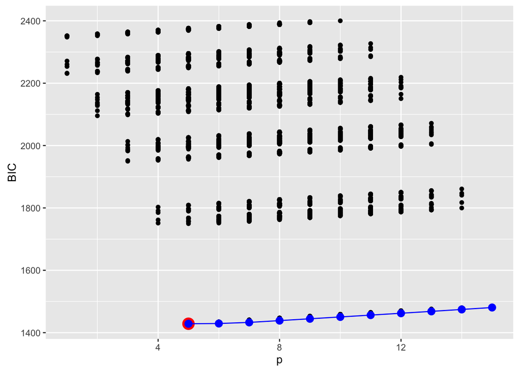

```r
library(ggplot2)
pathDF <- data.frame(size = unlist(path$keep[1,]),
            bic = unlist(path$keep[2,]))

ggplot(crit, aes(p,BIC)) +
  geom_point() +
  geom_point(data=crit[which.min(crit$BIC),], color="red", size=5) +
  geom_point(data=pathDF, aes(size-1, bic), color="blue", size=3)+
  geom_line(data=pathDF, aes(size-1, bic), color="blue")
```

# Task for lab classes

Use `apartments` data from `PBImisc` package.

Create a single large model with as many variables as you can imagine (plus interactions or transformations) that will predict price per square meter. Use model selection techniques to find smallest reasonable model.

Check if this model is the best one according to all criteria?

Work in pairs and be prepared to compare your models with others.

# Home work for 19 XI 2015

Read the chapter 2.6.3 from ,,Analiza danych z programem R, Modele liniowe mieszane’’ or in English (http://www.stat.umn.edu/geyer/5931/mle/sel.pdf).

Consider three approaches to variable selection:

- choose model with best BIC,
- choose model with best AIC,
- choose model with significant variables (i.e. marginal F test).

Generate three scenarios in such a way that in the first scenario the BIC will choose the right model in most cases, in the second scenario the AIC will be the best one and in the third scenario the selection with significant variables will find the right model most often.

In all scenarios the number of variables should be equal 10. The number of observations is up to you. The noise should be generated from N(0,1) distribution. For each variable you should decide if the variable effect is equal to 0 (if variable is not related with outcome) of is different than 0 (variable is important).

In your homework present results from 100 (or more) replications. For each criteria calculate the fraction of times that the criteria choose the right model.